# Taller2

Grupo J

10 de Enero 2022

## INTEGRANTES

Tauma Salvador, Alvaro Cesar 20181160

Echandia Orihuela, Kelly Lidia 20191302

Uriarte Zaga, Aron Salvad0r 20181161

Romero Cuenca, Mary Carmen 20191312

### TALLER2

El archivo seguro.csv contiene datos referidos a pólizas de seguros adquiridas por 200 personas, de las cuales se registran los siguientes atributos:

- age: Edad de la persona
- sex: Sexo de la persona
- bmi: Índice de masa corporal
- children: Número de hijos menores de 12 años
- smoker: Indicador de hábito de fumar (0: No, 1: Sí)
- region: Región de residencia de la persona
- charges: Monto mensual que paga, en dólares

Copie cada una de las preguntas y desarróllelas en un formato Rmd, de modo que genere un archivo HTML

# **0. Ejecute las siguientes tareas de preprocesamiento de datos, utilizando los códigos indicados en el recuadro inferior (requiere la carga previa de paquetes):**

```r
library(tidyverse)
```

### LECTURA DE DATOS

```r
datos <- read_csv("seguro.csv")
```

**a.** Retire la columna region

**b.** Renombre las columnas como edad, sexo, imc, nhijos, fuma, gastos

**c.** Recodifique las categorías de la variable sexo como masculino y femenino, fuma: sí y no.

```r
datos <- datos %>% select(-region) %>%
  rename(edad = 1,sexo = 2,imc = 3,nhijos = 4,fuma = 5,gastos = 6)%>%
  mutate(sexo = recode(sexo, male = "masculino", female = "femenino"),
         fuma = recode(fuma, yes = "si", no = "no"))
```

```r
datos
```

```
## # A tibble: 200 x 6
##     edad sexo        imc nhijos fuma  gastos
##    <dbl> <chr>     <dbl>  <dbl> <chr>  <dbl>
##  1    19 femenino   27.9      0 si      7.59
##  2    18 masculino  33.8      1 no     20.9
##  3    28 masculino  33        3 no     18.5
##  4    33 masculino  22.7      0 no      3.33
##  5    32 masculino  28.9      0 no     12.6
##  6    31 femenino   25.7      0 no      9.76
##  7    46 femenino   33.4      1 no      9.26
##  8    37 femenino   27.7      3 no     20.0
##  9    37 masculino  29.8      2 no     19.5
## 10    60 femenino   25.8      0 no     19.7
## # ... with 190 more rows
```

```r
#################################################################################################
```

```r
names(datos)
```

```
## [1] "edad"   "sexo"   "imc"    "nhijos" "fuma"   "gastos"
```

```r
attach(datos)
```

# **1. Se desea estudiar la influencia lineal de las variables sobre los gastos. Obtenga la estimación puntual de los coeficientes de regresión:**

$$\boldsymbol{\hat{\beta}}= \left(\textbf{X}'\textbf{X}\right)^{-1}\textbf{X}'\textbf{y}$$

**a.** Matricialmente (forme las matrices X e Y, y trabaje con ellas)

```r
X <- model.matrix(gastos~edad+sexo+imc+nhijos+fuma,data=datos)
```

$$\left(\textbf{X}'\textbf{X}\right)^{-1}$$

```r
C <- solve(t(X)%*%X);C
```

```
##                 (Intercept)          edad sexomasculino           imc
## (Intercept)    0.1879308682 -7.619716e-04 -1.414856e-02 -4.672852e-03
## edad          -0.0007619716  2.436234e-05  5.723450e-05 -5.922355e-06
## sexomasculino -0.0141485606  5.723450e-05  2.073834e-02  8.394179e-05
## imc           -0.0046728518 -5.922355e-06  8.394179e-05  1.593549e-04
## nhijos        -0.0026149384 -8.290348e-06  2.705475e-04 -2.657579e-05
## fumasi        -0.0051018006 -1.912507e-05 -3.769333e-03  2.224676e-05
##                      nhijos        fumasi
## (Intercept)   -2.614938e-03 -5.101801e-03
## edad          -8.290348e-06 -1.912507e-05
## sexomasculino  2.705475e-04 -3.769333e-03
## imc           -2.657579e-05  2.224676e-05
## nhijos         3.327013e-03  3.203856e-04
## fumasi         3.203856e-04  2.941197e-02
```

```r
dim(C) #matriz de dimencion k*k ... k:número de coeficientes de c
```

```
## [1] 6 6
```

```r
t
```

```
## function (x)
## UseMethod("t")
## <bytecode: 0x0000000026c1e578>
## <environment: namespace:base>
```

$$\textbf{X}'\textbf{y}$$

```r
y <- data.matrix(gastos)
dim(y)
```

```
## [1] 200   1
```

```r
dim(t(X))
```

```
## [1]   6 200
```

```r
t(X)%*%y
```

```
##                    [,1]
## (Intercept)     2781.70
## edad          117825.60
## sexomasculino   1308.77
## imc            87266.49
## nhijos          3103.62
## fumasi           738.26
```

$$\boldsymbol{\hat{\beta}}= \left(\textbf{X}'\textbf{X}\right)^{-1}\textbf{X}'\textbf{y}$$

```r
betasest <- solve(t(X)%*%X)%*%(t(X)%*%y)
```

**b.** Usando el modelo construido con el comando lm

```r
library(broom)
modelo <- lm(gastos~ ., data = datos)
modelo |> summary()
```

```
##
## Call:
## lm(formula = gastos ~ ., data = datos)
##
## Residuals:
##      Min       1Q   Median       3Q      Max
## -13.8275  -3.9415  -0.2676   4.2364  12.4101
##
## Coefficients:
##               Estimate Std. Error t value Pr(>|t|)
## (Intercept)   -5.19529    2.49684  -2.081 0.038770 *
## edad           0.26917    0.02843   9.468  < 2e-16 ***
## sexomasculino -0.08941    0.82943  -0.108 0.914265
## imc            0.25387    0.07271   3.492 0.000594 ***
## nhijos         0.34643    0.33221   1.043 0.298342
## fumasi         3.27114    0.98776   3.312 0.001106 **
## ---
## Signif. codes:  0 '***' 0.001 '**' 0.01 '*' 0.05 '.' 0.1 ' ' 1
##
## Residual standard error: 5.76 on 194 degrees of freedom
## Multiple R-squared:  0.3892, Adjusted R-squared:  0.3735
## F-statistic: 24.73 on 5 and 194 DF,  p-value: < 2.2e-16
```

$$\hat{y}=-5.19529+0.26917x1-0.08941x2+0.25387137x3+0.34643049x4+3.27114117x5$$

# **2. Calcule, utilizando matrices, las sumas de cuadrados de regresión, de error y total.**

```r
library(broom)
modelo |> aov() |> summary()
```

```
##              Df Sum Sq Mean Sq F value   Pr(>F)
## edad          1   3302    3302  99.535  < 2e-16 ***
## sexo          1      1       1   0.037 0.846905
## imc           1    405     405  12.213 0.000588 ***
## nhijos        1     29      29   0.876 0.350424
## fuma          1    364     364  10.967 0.001106 **
## Residuals   194   6436      33
## ---
## Signif. codes:  0 '***' 0.001 '**' 0.01 '*' 0.05 '.' 0.1 ' ' 1
```

```r
anva <- modelo |> anova();anva
```

```
## Analysis of Variance Table
##
## Response: gastos
##            Df Sum Sq Mean Sq F value    Pr(>F)
## edad        1 3301.9  3301.9 99.5352 < 2.2e-16 ***
## sexo        1    1.2     1.2  0.0374 0.8469054
## imc         1  405.1   405.1 12.2133 0.0005879 ***
## nhijos      1   29.1    29.1  0.8761 0.3504237
## fuma        1  363.8   363.8 10.9671 0.0011061 **
## Residuals 194 6435.5    33.2
## ---
## Signif. codes:  0 '***' 0.001 '**' 0.01 '*' 0.05 '.' 0.1 ' ' 1
```

### Sumas de cuadrados del total (SCT)

$$\text{SCT}= y^t(I_n-\frac{1}{n} J_n)y$$
$$(I_n-\frac{1}{n} J_n)$$

```r
n <- length(gastos);n # cantidad de valores de y
```

```
## [1] 200
```

```r
p <- length(names(datos))-1;p# 5variables indp y 1 indep
```

```
## [1] 5
```

```r
#I_n : matriz identidad de n*n
I_n <- diag(n)
```

```r
J_n <- matrix(c(rep(1,n*n)),nrow = n, ncol = n)#J_n : matriz de puro 1s ,dim nxn
#(diag(n)-(1/n)*J_n)%*%y
#dim((1/n)*J_n)
```

```r
matrix(c(rep(1,n*n)),nrow = n, ncol = n)
```

### SUMA DE CUADRADOS DEL TOTAL

```r
SCT <- t(y)%*%(I_n-(1/n)*matrix(c(rep(1,n*n)),nrow = n, ncol = n))%*%y;SCT
```

```
##          [,1]
## [1,] 10536.64
```

```r
SCT<-sum(anva[,2]);SCT
```

```
## [1] 10536.64
```

### SUMA DE CUADRADOS DE LA REGRESION

$$\text{SCREG}= y^t(H_{n*n}-\frac{1}{n} J_n)y$$

```r
#H_n : matriz hat  identidad de n*n
H <- X%*% solve(t(X)%*%X)%*%(t(X))
dim(H)
```

```
## [1] 200 200
```

```r
SCREGRE <- t(y)%*%(H-(1/n)*J_n)%*%y;SCREGRE
```

```
##          [,1]
## [1,] 4101.119
```

### SUMA DE CUADRADOS DEL ERROR

$$\text{SCERROR}= y^t(I_{n*n}-H_n)y$$

```r
SCRERROR <- t(y)%*%(I_n-H)%*%y;SCRERROR
```

```
##          [,1]
## [1,] 6435.518
```

```r
anva[p+1,2]
```

```
## [1] 6435.518
```

# **3. Obtenga la matriz de varianzas – covarianzas estimadas para el vector de coeficientes de regresión estimados:**

```r
#El valor de σ2 es estimado mediante el Cuadrado Medio del Error (sacado del anva)
summary(modelo)$sigma**2
```

```
## [1] 33.17278
```

**a**.Matricialmente (utilice la matriz X y obtenga el CME a partir de la pregunta anterior)

```r
summary(modelo)$sigma**2*solve(t(X)%*%X)
```

```
##               (Intercept)          edad sexomasculino           imc
## (Intercept)    6.23418845 -0.0252767111  -0.469347021 -0.1550114619
## edad          -0.02527671  0.0008081664   0.001898627 -0.0001964610
## sexomasculino -0.46934702  0.0018986271   0.687948251  0.0027845821
## imc           -0.15501146 -0.0001964610   0.002784582  0.0052862449
## nhijos        -0.08674476 -0.0002750138   0.008974810 -0.0008815927
## fumasi        -0.16924088 -0.0006344315  -0.125039251  0.0007379868
##                      nhijos        fumasi
## (Intercept)   -0.0867447649 -0.1692408836
## edad          -0.0002750138 -0.0006344315
## sexomasculino  0.0089748104 -0.1250392514
## imc           -0.0008815927  0.0007379868
## nhijos         0.1103662504  0.0106280796
## fumasi         0.0106280796  0.9756766517
```

**b.** Usando la función vcov

```r
vcov(modelo)
```

```
##               (Intercept)          edad sexomasculino           imc
## (Intercept)    6.23418845 -0.0252767111  -0.469347021 -0.1550114619
## edad          -0.02527671  0.0008081664   0.001898627 -0.0001964610
## sexomasculino -0.46934702  0.0018986271   0.687948251  0.0027845821
## imc           -0.15501146 -0.0001964610   0.002784582  0.0052862449
## nhijos        -0.08674476 -0.0002750138   0.008974810 -0.0008815927
## fumasi        -0.16924088 -0.0006344315  -0.125039251  0.0007379868
##                      nhijos        fumasi
## (Intercept)   -0.0867447649 -0.1692408836
## edad          -0.0002750138 -0.0006344315
## sexomasculino  0.0089748104 -0.1250392514
## imc           -0.0008815927  0.0007379868
## nhijos         0.1103662504  0.0106280796
## fumasi         0.0106280796  0.9756766517
```

# **4.Muestre una elipse de 96% de confianza para las variables IMC y Número de hijos**

```r
library(car)
names(datos)
```

```
## [1] "edad"   "sexo"   "imc"    "nhijos" "fuma"   "gastos"
```

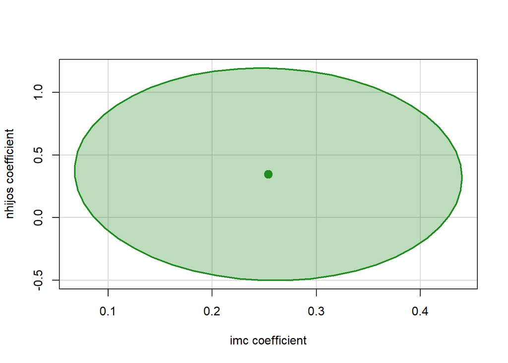

```r
modelo |> confidenceEllipse(levels     = 0.96,
                            fill       = T,
                            which.coef = c(4,5),
                            col        = "forestgreen")
```

# **5. Escriba el cuadro ANVA, y pruebe la hipótesis de significancia de la regresión con un α = 0.05**

**a.** Utilice el criterio del pvalor

```r
modelo <- lm(gastos~ ., data = datos)
modelo %>% summary()
```

```
##
## Call:
## lm(formula = gastos ~ ., data = datos)
##
## Residuals:
##      Min       1Q   Median       3Q      Max
## -13.8275  -3.9415  -0.2676   4.2364  12.4101
##
## Coefficients:
##               Estimate Std. Error t value Pr(>|t|)
## (Intercept)   -5.19529    2.49684  -2.081 0.038770 *
## edad           0.26917    0.02843   9.468  < 2e-16 ***
## sexomasculino -0.08941    0.82943  -0.108 0.914265
## imc            0.25387    0.07271   3.492 0.000594 ***
## nhijos         0.34643    0.33221   1.043 0.298342
## fumasi         3.27114    0.98776   3.312 0.001106 **
## ---
## Signif. codes:  0 '***' 0.001 '**' 0.01 '*' 0.05 '.' 0.1 ' ' 1
##
## Residual standard error: 5.76 on 194 degrees of freedom
## Multiple R-squared:  0.3892, Adjusted R-squared:  0.3735
## F-statistic: 24.73 on 5 and 194 DF,  p-value: < 2.2e-16
```

p-value: < 2.2e-16 **pvalue < 0.05** Se rechaza H0 Conclusion: Al menos uno de los coeficientes es distinto de 0 lo que implicaria que al menos unas de las variables contribuyen significativa al modelo

**b.** Utilice el criterio de Fcalculado

```r
anva <- modelo |> anova();anva
```

```
## Analysis of Variance Table
##
## Response: gastos
##            Df Sum Sq Mean Sq F value    Pr(>F)
## edad        1 3301.9  3301.9 99.5352 < 2.2e-16 ***
## sexo        1    1.2     1.2  0.0374 0.8469054
## imc         1  405.1   405.1 12.2133 0.0005879 ***
## nhijos      1   29.1    29.1  0.8761 0.3504237
## fuma        1  363.8   363.8 10.9671 0.0011061 **
## Residuals 194 6435.5    33.2
## ---
## Signif. codes:  0 '***' 0.001 '**' 0.01 '*' 0.05 '.' 0.1 ' ' 1
```

```r
k <- length(names(datos));k #numero de coeficientes de regresion betas coicide con el numero de varibales indp y dep (tener cuidado con el codigo!)
```

```
## [1] 6
```

```r
n <- length(gastos);n # cantidad de valores de y
```

```
## [1] 200
```

```r
p <- length(names(datos))-1;p# 5variables indp y 1 indep
```

```
## [1] 5
```

### GRADOS DE LIBERTAD

```r
GLREGRE <- k-1;GLREGRE
```

```
## [1] 5
```

```r
GLERROR <- n-k;GLERROR
```

```
## [1] 194
```

```r
GLTOTAL <- n-1;GLTOTAL
```

```
## [1] 199
```

### SUMA DE CUADRADOS

```r
SCREGRE
```

```
##          [,1]
## [1,] 4101.119
```

```r
SCRERROR
```

```
##          [,1]
## [1,] 6435.518
```

```r
SCT
```

```
## [1] 10536.64
```

### CUADRADOS MEDIOS

```r
CMREGRE <- SCREGRE/GLREGRE;CMREGRE
```

```
##          [,1]
## [1,] 820.2238
```

```r
CMERROR <- SCRERROR/GLERROR;CMERROR
```

```
##          [,1]
## [1,] 33.17278
```

### FCALCULADO

```r
FCALCULADO <- CMREGRE/CMERROR;FCALCULADO
```

```
##          [,1]
## [1,] 24.72581
```

```r
Fcritico <- qf(1-0.05,k-1,n-k);Fcritico
```

```
## [1] 2.260647
```

```r
FCALCULADO>Fcritico #SI ES CORRECTO H0 SE RECHAZA
```

```
##      [,1]
## [1,] TRUE
```

# **6. Plantee y desarrolle una prueba de hipótesis para una de las variables predictoras cuantitativas**

```r
modelo %>% summary()
```

```
##
## Call:
## lm(formula = gastos ~ ., data = datos)
##
## Residuals:
##      Min       1Q   Median       3Q      Max
## -13.8275  -3.9415  -0.2676   4.2364  12.4101
##
## Coefficients:
##               Estimate Std. Error t value Pr(>|t|)
## (Intercept)   -5.19529    2.49684  -2.081 0.038770 *
## edad           0.26917    0.02843   9.468  < 2e-16 ***
## sexomasculino -0.08941    0.82943  -0.108 0.914265
## imc            0.25387    0.07271   3.492 0.000594 ***
## nhijos         0.34643    0.33221   1.043 0.298342
## fumasi         3.27114    0.98776   3.312 0.001106 **
## ---
## Signif. codes:  0 '***' 0.001 '**' 0.01 '*' 0.05 '.' 0.1 ' ' 1
##
## Residual standard error: 5.76 on 194 degrees of freedom
## Multiple R-squared:  0.3892, Adjusted R-squared:  0.3735
## F-statistic: 24.73 on 5 and 194 DF,  p-value: < 2.2e-16
```

### Prueba de significancia de regresión de la varible edad (b1)

$H_0:\beta_1=0$ $H_1:\beta_1\neq0$

(pv< 2e-16) <0.05 Rechaza HO

Conclusion: Si hay contribucion de la varibale edad al modelo o si hay efecto lineal de la variable sobre el modelo

# **7.Plantee y desarrolle una prueba de hipótesis para una de las variables predictoras cualitativas.**

### Prueba de significancia de regresión de la varible sexo (b2)

$H_0:\beta_2=0$ $H_1:\beta_2\neq0$

# **8. Plantee una situación donde el punto evaluado para una predicción NO corresponda a una extrapolación**

$$\textbf{x}'\left(\textbf{X}'\textbf{X}\right)^{-1}\textbf{x} > h_{max},\qquad h_{max}=max(h_{11},...,h_{nn})$$

```r
x <- c(1,33,1,22.705,0,0)# 33años,masculino,22.705 imc, 0numero de hijos,0 si fuma
H <- X%*%solve(t(X)%*%X)%*%t(X)#matriz hat
hmax <-  H %>% diag %>% max;hmax
```

```
## [1] 0.0801585
```

```r
t(x)%*%solve(t(X)%*%X)%*%x
```

```
##            [,1]
## [1,] 0.02528297
```

```r
t(x)%*%solve(t(X)%*%X)%*%x > hmax
```

```
##       [,1]
## [1,] FALSE
```

Notamos que en la verificacion de extrapolacion, la variable h max es mayor, así que no existe extrapolacion. Por lo tanto se recomienda hacer estimaciones, ya que la estimación resultaria en nuestro rango de datos.

# **9.Plantee una situación donde el punto evaluado para una predicción SÍ corresponda a una extrapolación**

$$\textbf{x}'\left(\textbf{X}'\textbf{X}\right)^{-1}\textbf{x} > h_{max},\qquad h_{max}=max(h_{11},...,h_{nn})$$

```r
x = c(1,56,1,18,9,1)# 56años,1 masculino,18 imc, 9 numero de hijos,1 si fuma
H <- X%*%solve(t(X)%*%X)%*%t(X)#matriz hat
hmax <-  H %>% diag %>% max;hmax
```

```
## [1] 0.0801585
```

```r
t(x)%*%solve(t(X)%*%X)%*%x
```

```
##           [,1]
## [1,] 0.2787499
```

```r
t(x)%*%solve(t(X)%*%X)%*%x > hmax
```

```
##      [,1]
## [1,] TRUE
```

Conclusión Notamos que en la verificacion de extrapolacion, h max es menor, asi que sí existe extrapolacion. Por lo tanto, no se recomienda hacer estimaciones, ya que la estimación resultaria fuera de nuestro rango de datos.

# **10. Verifique si se cumple el supuesto de normalidad de errores**

```r
################ NORMALIDAD ###############

library(dplyr)
library(skimr)
library(broom)
library(broom)
modelo |> summary()
```

```
##
## Call:
## lm(formula = gastos ~ ., data = datos)
##
## Residuals:
##      Min       1Q   Median       3Q      Max
## -13.8275  -3.9415  -0.2676   4.2364  12.4101
##
## Coefficients:
##               Estimate Std. Error t value Pr(>|t|)
## (Intercept)   -5.19529    2.49684  -2.081 0.038770 *
## edad           0.26917    0.02843   9.468  < 2e-16 ***
## sexomasculino -0.08941    0.82943  -0.108 0.914265
## imc            0.25387    0.07271   3.492 0.000594 ***
## nhijos         0.34643    0.33221   1.043 0.298342
## fumasi         3.27114    0.98776   3.312 0.001106 **
## ---
## Signif. codes:  0 '***' 0.001 '**' 0.01 '*' 0.05 '.' 0.1 ' ' 1
##
## Residual standard error: 5.76 on 194 degrees of freedom
## Multiple R-squared:  0.3892, Adjusted R-squared:  0.3735
## F-statistic: 24.73 on 5 and 194 DF,  p-value: < 2.2e-16
```

```r
modelo |> augment()
```

```
## # A tibble: 200 x 12
##    gastos  edad sexo     imc nhijos fuma  .fitted  .resid   .hat .sigma  .cooksd
##     <dbl> <dbl> <chr>  <dbl>  <dbl> <chr>   <dbl>   <dbl>  <dbl>  <dbl>    <dbl>
##  1   7.59    19 femen~  27.9      0 si      10.3  -2.68   0.0445   5.77  1.76e-3
##  2  20.9     18 mascu~  33.8      1 no       8.48 12.4    0.0240   5.70  1.95e-2
##  3  18.5     28 mascu~  33        3 no      11.7   6.86   0.0290   5.75  7.26e-3
##  4   3.33    33 mascu~  22.7      0 no       9.36 -6.03   0.0253   5.76  4.86e-3
##  5  12.6     32 mascu~  28.9      0 no      10.7   1.98   0.0171   5.77  3.49e-4
##  6   9.76    31 femen~  25.7      0 no       9.68  0.0765 0.0197   5.77  6.02e-7
##  7   9.26    46 femen~  33.4      1 no      16.0  -6.76   0.0124   5.75  2.92e-3
##  8  20.0     37 femen~  27.7      3 no      12.8   7.10   0.0241   5.75  6.42e-3
##  9  19.5     37 mascu~  29.8      2 no      12.9   6.59   0.0161   5.75  3.62e-3
## 10  19.7     60 femen~  25.8      0 no      17.5   2.23   0.0307   5.77  8.14e-4
## # ... with 190 more rows, and 1 more variable: .std.resid <dbl>
```

```r
(modelo |> residuals() -> residuales)
```

```
##            1            2            3            4            5            6
##  -2.68299779  12.41006571   6.86103301  -6.03189612   1.97961345   0.07652233
##            7            8            9           10           11           12
##  -6.76219671   7.10449651   6.58974833   2.22534244   0.14906816   7.83162862
##           13           14           15           16           17           18
##  -4.67926909   6.07288179   0.75050299   5.09890089   0.82810953  -2.03965681
##           19           20           21           22           23           24
##   5.85043602  -5.11305137 -10.80526001   8.90847379  11.51271865 -13.82747019
##           25           26           27           28           29           30
##  -5.37201385  -3.61206194  -3.38273774   7.18770986  -0.45607826   2.78105101
##           31           32           33           34           35           36
##   5.24410936  -4.13030524  -6.66171904   2.19019685 -13.42040983   0.18524434
##           37           38           39           40           41           42
##   4.40888694  -4.69411429   1.53688803 -10.15581767  -2.26765018  -1.74099785
##           43           44           45           46           47           48
##  -3.30681773  -0.37591938  -0.33593772  -4.37878461   2.20152239  -0.96844032
##           49           50           51           52           53           54
##   7.73791393 -13.61908632   2.76615233  -1.70773108  11.11880432  -0.01717488
##           55           56           57           58           59           60
##  11.21582291   5.37730305  -7.60860815  -2.30691479  -3.91661311  -1.54747297
##           61           62           63           64           65           66
##  -5.61461148   5.77454322  -6.61892327   7.68808272  -2.83094797  -0.88572799
##           67           68           69           70           71           72
##  -0.91301815   1.32104088   3.52107913   3.77981157   4.09337488   0.60309738
##           73           74           75           76           77           78
##  -2.27354146   4.26026863   3.45249889   7.24812166   9.98101760   1.44218680
##           79           80           81           82           83           84
##   0.31830894  -0.19935098   6.03882161  -0.40660772   0.86485871   2.31252333
##           85           86           87           88           89           90
##  -8.81254602   6.88588296   6.62110139   2.55673845  -6.21869942  -8.62824458
##           91           92           93           94           95           96
##  -2.16255631  -2.48163560   8.95054079  -1.82604569  -2.86145845  -0.43840421
##           97           98           99          100          101          102
##   1.52184058   5.28242145   3.69557718  -2.40443162   9.87718344  -1.36381594
##          103          104          105          106          107          108
##  -6.51501643  11.42994934  -0.44421757  -0.54091499   4.10477720  -5.49472931
##          109          110          111          112          113          114
##   3.42574834   5.33780780   6.33565809 -11.03163569   0.38635409   2.58453875
##          115          116          117          118          119          120
##  -1.62710567  -1.46466069   0.77819230   2.48876419  -7.79148854 -11.34965512
```

[output cut: 13 more lines]

```
##  -2.88590570  -7.40262056  -5.33144178  -3.68750039  10.98623384   6.78401873
##          163          164          165          166          167          168
##  -8.90995398  -4.01622168  -7.83915512  -4.32476306  -0.85340379  -1.58439061
##          169          170          171          172          173          174
##  -5.62473223   4.35851521  -3.30075035   2.86330657   2.53794526  -5.10664383
##          175          176          177          178          179          180
##   5.48998744  -2.05420895   4.46705644   4.65030824   6.44394881  -0.72687801
##          181          182          183          184          185          186
##  -8.57633016   1.60212385  -2.97095404   1.19728004  -5.99273791  -2.77161612
##          187          188          189          190          191          192
##   9.26830536 -11.53358014  -7.50156987  -6.86516874  -6.38909328  -7.07608484
##          193          194          195          196          197          198
##   1.96092642   3.87263078  -1.08105890  -5.95535811   4.48086833  -0.36072451
##          199          200
##  -4.18451220   2.20395662
```

```r
"HISTOGRAMA"
```

```
## [1] "HISTOGRAMA"
```